# Your Turn Solutions

Haley Jeppson, Joe Papio, Sam Tyner

June 12, 2017

## Motivating Example

Try playing with chunks of code from this session to further investigate the tips data:

1. Get a summary of the total bill values

```r
#tips <- read.csv("http://heike.github.io/rwrks/01-r-intro/data/tips.csv")
tips <- read.csv("../data/tips.csv")


summary(tips$total_bill)
```

```
##    Min. 1st Qu.  Median    Mean 3rd Qu.    Max.
##    3.07   13.35   17.80   19.79   24.13   50.81
```

2. Make side by side boxplots of tip rates for different days of the week

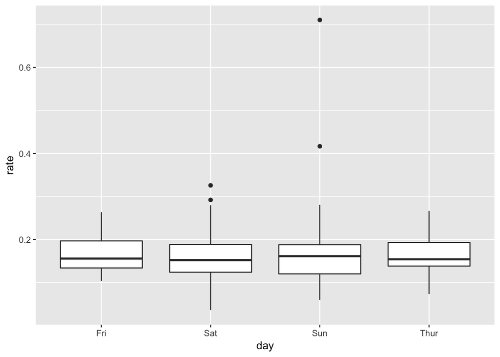

```r
library(ggplot2)

tips$rate <- tips$tip / tips$total_bill

qplot(day, rate, geom = "boxplot", data = tips)
```

3. Find the average tip value for smokers

```r
mean(tips$tip[tips$smoker == "Yes"])
```

```
## [1] 3.00871
```

## Basics

Using the R Reference Card (and the Help pages, if needed), do the following:

1. Find out how many rows and columns the `iris’ data set has. Figure out at least 2 ways to do this. *Hint: “Variable Information” section on the first page of the reference card!*

```r
nrow(iris)
```

```
## [1] 150
```

```r
ncol(iris)
```

```
## [1] 5
```

```r
dim(iris)
```

```
## [1] 150   5
```

2. Use the `rep` function to construct the following vector: 1 1 2 2 3 3 4 4 5 5 *Hint: “Data Creation” section of the reference card*

```r
rep(1:5, each = 2)
```

```
##  [1] 1 1 2 2 3 3 4 4 5 5
```

3. Use `rep` to construct this vector: 1 2 3 4 5 1 2 3 4 5 1 2 3 4 5

```r
rep(1:5, times = 3)
```

```
##  [1] 1 2 3 4 5 1 2 3 4 5 1 2 3 4 5
```

1. Find out how many people tipped over 20%. *Hint: if you use the `sum` function on a logical vector, it’ll return how many TRUEs are in the vector:*

```r
sum(c(TRUE, TRUE, FALSE, TRUE, FALSE))
```

```
## [1] 3
```

```r
sum(tips$rate > .2)
```

```
## [1] 39
```

2. **More Challenging**: Calculate the sum of the total bills of anyone who tipped over 20%

```r
sum(tips$total_bill[tips$rate > .2])
```

```
## [1] 619.23
```

1. Read up on the dataset (`?diamonds`)
2. Plot price by carat (use qplot - go back to the motivating example for help with the syntax)

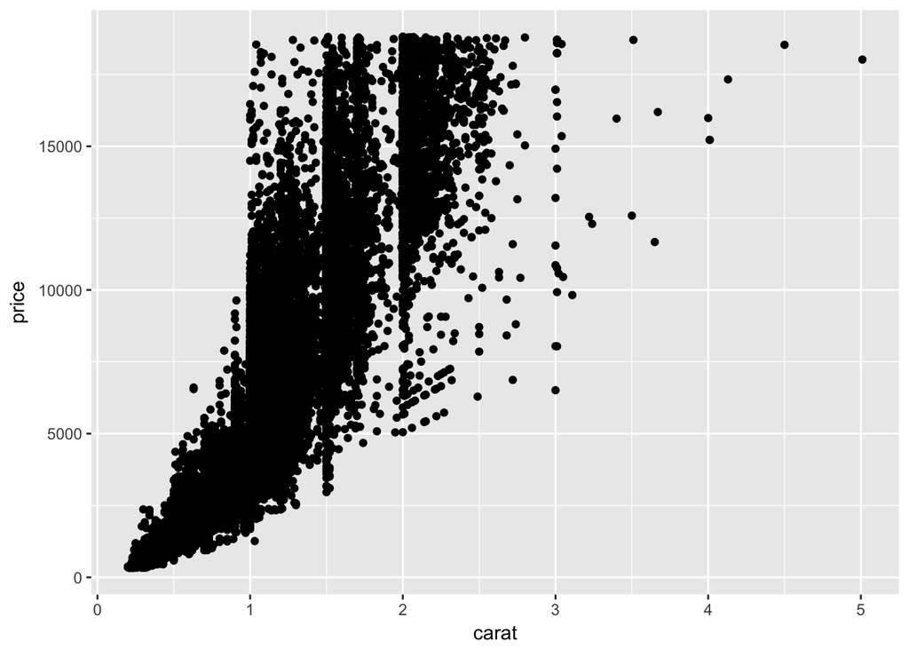

```r
qplot(carat, price, data = diamonds)
```

3. Create a variable `ppc` for price/carat. Store this variable as a column in the diamonds data

```r
diamonds$ppc <- diamonds$price / diamonds$carat
```

4. Make a histogram of all ppc values that exceed $10000 per carat.

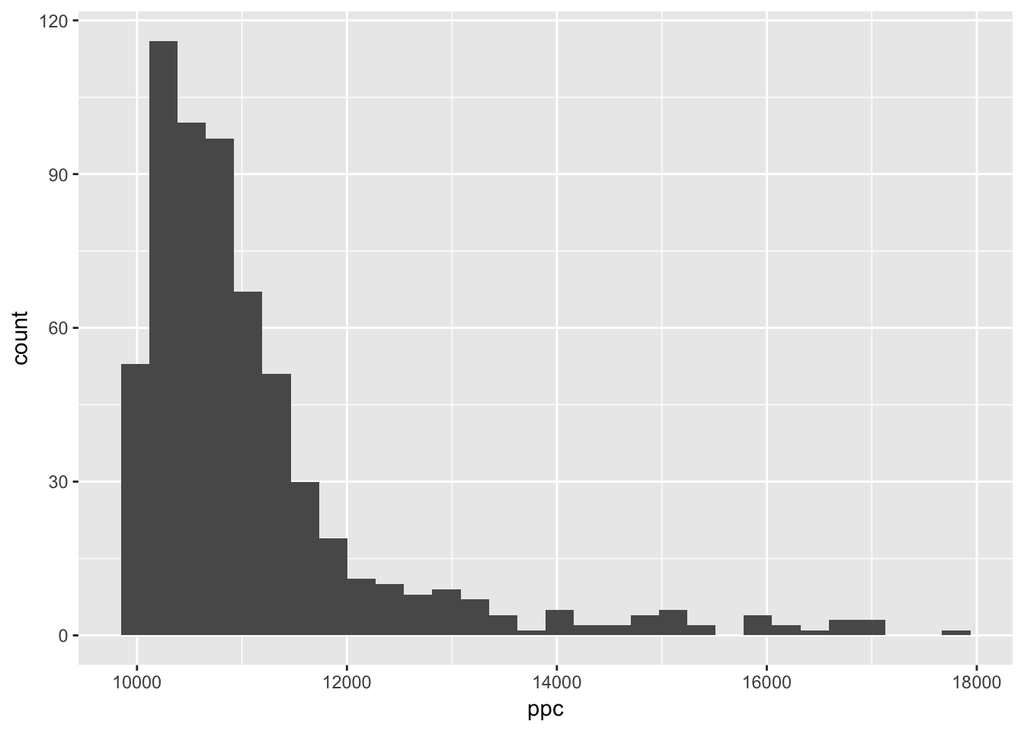

```r
qplot(ppc, geom = "histogram", data = diamonds[diamonds$ppc > 10000,])
```

5. Explore any other interesting relationships you find

## Data Structures

1. Make a data frame with column 1: 1,2,3,4,5,6 and column 2: a,b,a,b,a,b

```r
mydf <- data.frame(col1 = 1:6, col2 = rep(c("a", "b"), times = 3))
```

2. Select only rows with value “a” in column 2 using logical vector

```r
mydf[mydf$col2 == "a",]
```

```
##   col1 col2
## 1    1    a
## 3    3    a
## 5    5    a
```

3. `mtcars` is a built in data set like `iris`: Extract the 4th row of the `mtcars` data.

```r
mtcars[4,]
```

```
##                 mpg cyl disp  hp drat    wt  qsec vs am gear carb
## Hornet 4 Drive 21.4   6  258 110 3.08 3.215 19.44  1  0    3    1
```

1. Create a list containing a vector and a 2x3 data frame

```r
mylist <- list(vec = 1:6, df = data.frame(x = 1:2, y = 3:4, z = 5:6))
```

2. Use indexing to select the data frame from your list

```r
mylist[[2]]
```

```
##   x y z
## 1 1 3 5
## 2 2 4 6
```

3. Use further indexing to select the first row from the data frame in your list

```r
mylist[[2]][1,]
```

```
##   x y z
## 1 1 3 5
```

1. View the top 8 rows of mtcars data

```r
head(mtcars, n = 8)
```

```
##                    mpg cyl  disp  hp drat    wt  qsec vs am gear carb
## Mazda RX4         21.0   6 160.0 110 3.90 2.620 16.46  0  1    4    4
## Mazda RX4 Wag     21.0   6 160.0 110 3.90 2.875 17.02  0  1    4    4
## Datsun 710        22.8   4 108.0  93 3.85 2.320 18.61  1  1    4    1
## Hornet 4 Drive    21.4   6 258.0 110 3.08 3.215 19.44  1  0    3    1
## Hornet Sportabout 18.7   8 360.0 175 3.15 3.440 17.02  0  0    3    2
## Valiant           18.1   6 225.0 105 2.76 3.460 20.22  1  0    3    1
## Duster 360        14.3   8 360.0 245 3.21 3.570 15.84  0  0    3    4
## Merc 240D         24.4   4 146.7  62 3.69 3.190 20.00  1  0    4    2
```

2. What type of object is the mtcars data set?

```r
str(mtcars)
```

```
## 'data.frame':    32 obs. of  11 variables:
##  $ mpg : num  21 21 22.8 21.4 18.7 18.1 14.3 24.4 22.8 19.2 ...
##  $ cyl : num  6 6 4 6 8 6 8 4 4 6 ...
##  $ disp: num  160 160 108 258 360 ...
##  $ hp  : num  110 110 93 110 175 105 245 62 95 123 ...
##  $ drat: num  3.9 3.9 3.85 3.08 3.15 2.76 3.21 3.69 3.92 3.92 ...
##  $ wt  : num  2.62 2.88 2.32 3.21 3.44 ...
##  $ qsec: num  16.5 17 18.6 19.4 17 ...
##  $ vs  : num  0 0 1 1 0 1 0 1 1 1 ...
##  $ am  : num  1 1 1 0 0 0 0 0 0 0 ...
##  $ gear: num  4 4 4 3 3 3 3 4 4 4 ...
##  $ carb: num  4 4 1 1 2 1 4 2 2 4 ...
```

3. How many rows are in iris data set? (try finding this using dim or indexing + length)

```r
dim(iris)
```

```
## [1] 150   5
```

4. Summarize the values in each column in iris data set

```r
summary(iris)
```

```
##   Sepal.Length    Sepal.Width     Petal.Length    Petal.Width
##  Min.   :4.300   Min.   :2.000   Min.   :1.000   Min.   :0.100
##  1st Qu.:5.100   1st Qu.:2.800   1st Qu.:1.600   1st Qu.:0.300
##  Median :5.800   Median :3.000   Median :4.350   Median :1.300
##  Mean   :5.843   Mean   :3.057   Mean   :3.758   Mean   :1.199
##  3rd Qu.:6.400   3rd Qu.:3.300   3rd Qu.:5.100   3rd Qu.:1.800
##  Max.   :7.900   Max.   :4.400   Max.   :6.900   Max.   :2.500
##        Species
##  setosa    :50
##  versicolor:50
##  virginica :50
##
##
##
```

## Packages and Programming

1. Create a function that takes numeric input and provides the mean and a 95% confidence interval for the mean for the data (the t.test function could be useful)

```r
mean_and_ci <- function(x) {
    themean <- mean(x)
    theci <- t.test(x)$conf.int

    return(list(mean = themean, ci = theci))
}
```

2. Add checks to your function to make sure the data is either numeric or logical. If it is logical convert it to numeric.

```r
mean_and_ci <- function(x) {
    if (!is.numeric(x) && !is.logical(x)) stop("Need logical or numeric data")

    x <- as.numeric(x)

    themean <- mean(x)
    theci <- t.test(x)$conf.int

    return(list(mean = themean, ci = theci))
}
```

3. Loop over the columns of the diamonds data set and apply your function to all of the numeric columns.

```r
for (i in 1:ncol(diamonds)) {
    if (is.numeric(diamonds[,i])) print(mean_and_ci(diamonds[,i]))
}
```

## RMarkdown Basics

Study the second page of the R Markdown Reference Guide and go back to the Hello R Markdown example

**Easy**: Modify the figure sizing and alignment.

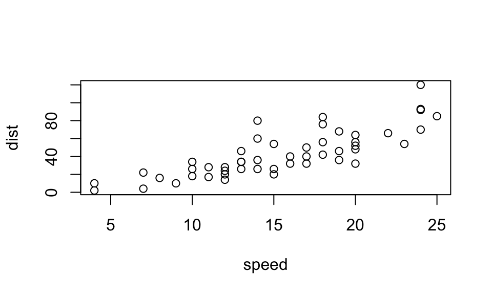

```r
plot(cars)
```

**Medium**: Add a figure caption.

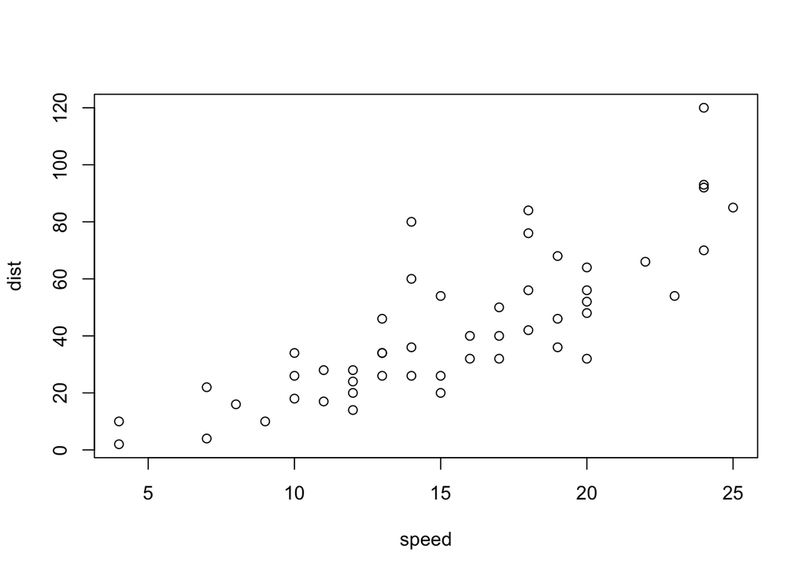

This is a caption

```r
plot(cars)
```

**Hard**: Can you create an animation? (Hint: look at the `fig.show` chunk option – you might need to the **animation** package for this)

See Haley, Joe, or Sam for an explanation of this.